# RPiSM projekt nr 2 - zad.1

Aleksandra Talaga, Urszula Zastawna, Karolina Węgrzyn

2024-01-13

# Użyte biblioteki

```r
library(ggplot2)
library(dplyr)
library(moments)
library(readxl)
library(BSDA)
```

# Wczytanie pliku z danymi

Dane zostały pobrane ze strony stooq.pl i dotyczą tygodniowych notowań spółki mBank SA. Do wszystkich poleceń użuywamy logarytmicznych stóp zwrotu (od zamknięcia do zamknięcia).  
Logarytmiczne stopy zwrotu zostały policzone w Excelu. Wgrywamy ten plik:

```r
mbk_tyg <- read_excel("C:/RFiles/mbk_tyg.xlsx")
```

Wybieramy potrzebną kolumnę **‘Stopy zwrotu’** i usuwamy pierwszy wiersz, ponieważ nie zawiera wartości (NA):

```r
tyg_stopy <- mbk_tyg$`Stopy zwrotu`

tyg_stopy <- tyg_stopy[-1]
```

### Przygotowanie 1/3 danych

Wyznaczamy, ile danych wziąć, aby była 1/3:

```r
liczba_danych_do_losowania <- floor(length(tyg_stopy)/3)
```

Losujemy z wczytanego pliku tyle wierszy, ile wyznaczyliśmy w zmiennej liczba_danych_do_losowania (od drugiego wiersza, ponieważ pierwszy nie zawiera wartości). Wybieramy potrzebną kolumnę **‘Stopy zwrotu’**:

```r
set.seed(20)
mbk_tyg_czesc <- mbk_tyg[sample(2:nrow(mbk_tyg), liczba_danych_do_losowania, replace = FALSE), ]
tyg_stopy_czesc <- mbk_tyg_czesc$`Stopy zwrotu`
```

# Podstawowe charakterystyki rozkładu stóp zwrotu (zad.2.)

### Wszystkie dane

```r
stats_tyg_stopy <- data.frame(
  srednia = mean(tyg_stopy, na.rm = T),
  odchylenie = sd(tyg_stopy, na.rm = T),
  skosnosc = skewness(tyg_stopy, na.rm = T),
  kurtoza = kurtosis(tyg_stopy, na.rm = T)
)
stats_tyg_stopy
```

| srednia | odchylenie | skosnosc | kurtoza |
| --- | --- | --- | --- |
| 0.002029493 | 0.06819358 | 0.06038403 | 3.756825 |

Średnia jest bardzo bliska 0, ponieważ wynosi 0.002, odchylenie standardowe i współczynnik skośności także są niewielkie. Zatem można powiedzieć, że rozkład jest symetryczny względem 0. Kurtoza wyniosła 3.75, zatem jest trochę wyższa od kurtozy rozkładu normalnego, czyli rozkład jest lekko leptokurtyczny.

### 1/3 danych

```r
stats_tyg_stopy_czesc <- data.frame(
  srednia = mean(tyg_stopy_czesc, na.rm = T),
  odchylenie = sd(tyg_stopy_czesc, na.rm = T),
  skosnosc = skewness(tyg_stopy_czesc, na.rm = T),
  kurtoza = kurtosis(tyg_stopy_czesc, na.rm = T)
)
stats_tyg_stopy_czesc
```

| srednia | odchylenie | skosnosc | kurtoza |
| --- | --- | --- | --- |
| 0.006261234 | 0.06617534 | 0.1468865 | 3.605311 |

Tutaj także średnia, odchylenie standardowe i współczynnik skośności są bliskie 0, zatem można powiedzieć, że rozkład jest symetryczny względem 0. W tym przypadku kurtoza wyniosła 3.6, zatem także jest trochę wyższa od kurtozy rozkładu normalnego, czyli rozkład jest lekko leptokurtyczny.

# Graficzne przedstawienie rozkładu stóp zwrotu (zad.2.)

## Histogram

### Wszystkie dane

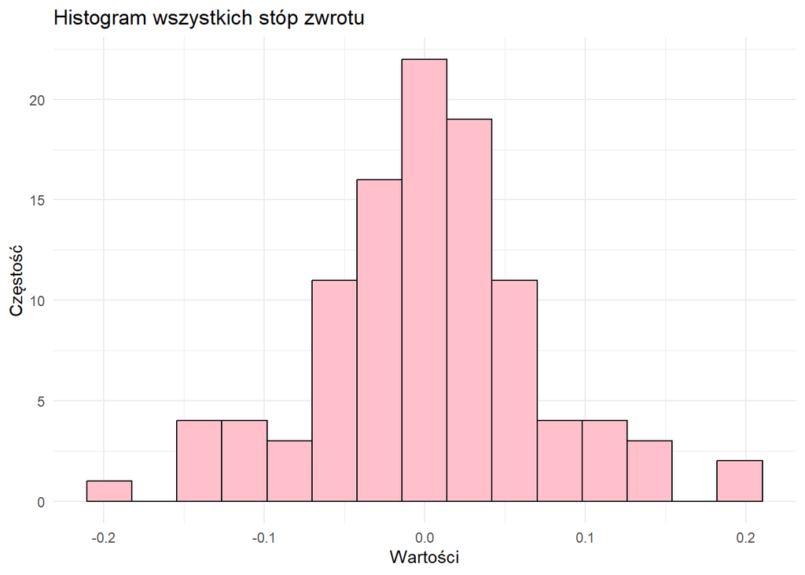

```r
ggplot()+
  geom_histogram(mapping=aes(x=tyg_stopy),
                 bins=15,
                 fill="pink",
                 colour="black")+
  labs(title="Histogram wszystkich stóp zwrotu", x="Wartości", y="Częstość")+
  theme_minimal()
```

Histogram potwierdza wnioski dotyczące symetryczności rozkładu. Najwięcej wartości jest skupionych wokół 0.

### 1/3 danych

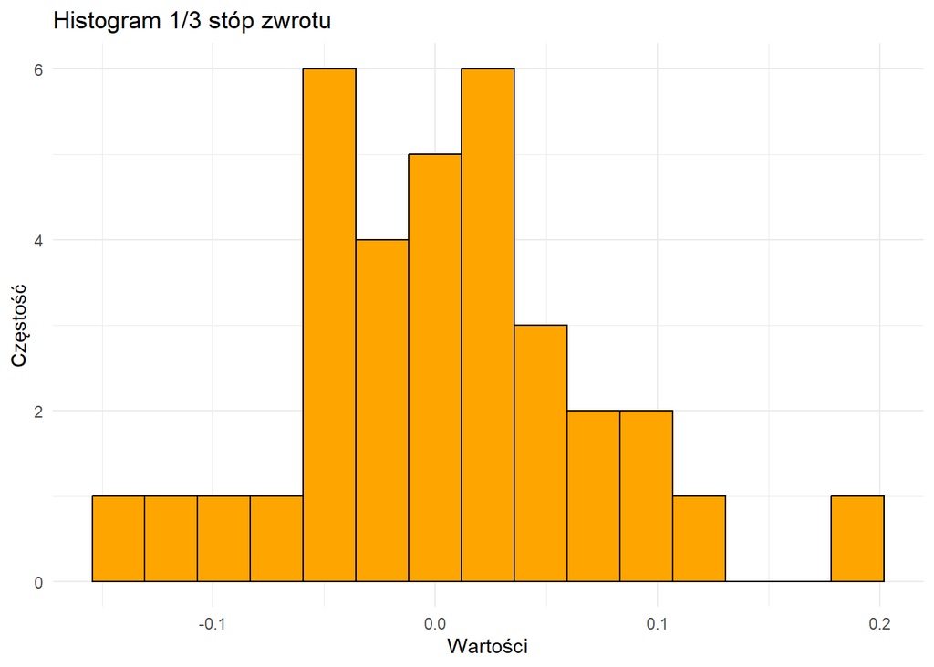

```r
ggplot()+
  geom_histogram(mapping=aes(x=tyg_stopy_czesc),
                 bins=15,
                 fill="orange",
                 colour="black")+
  labs(title="Histogram 1/3 stóp zwrotu", x="Wartości", y="Częstość")+
  theme_minimal()
```

**Wniosek:** Oba histogramy potwierdzają wnioski dotyczące symetryczności rozkładu. Najwięcej wartości jest skupionych wokół 0.

## Wykres pudełkowy

### Wszystkie dane

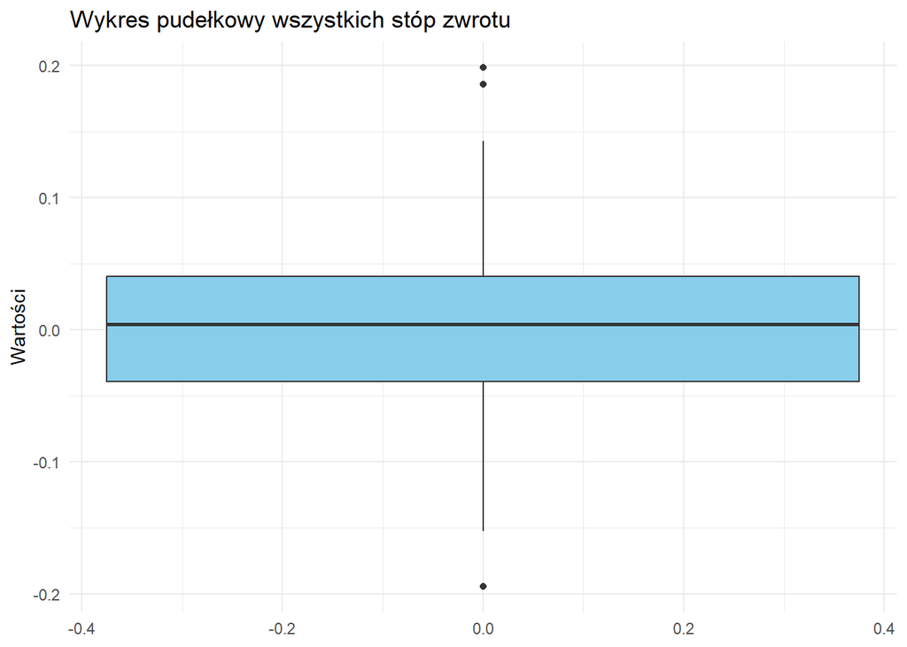

```r
ggplot()+
  geom_boxplot(aes(y=tyg_stopy), fill="skyblue")+
  labs(title="Wykres pudełkowy wszystkich stóp zwrotu", y="Wartości")+
  theme_minimal()
```

### 1/3 danych

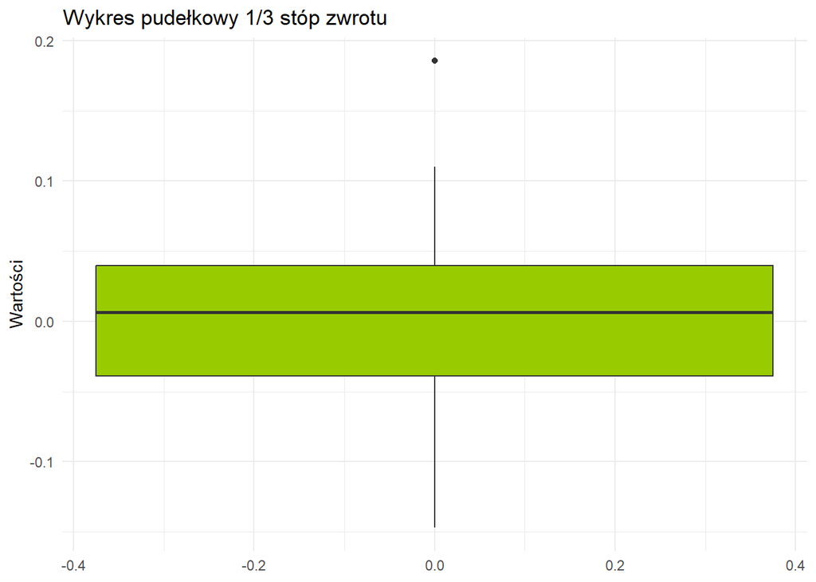

```r
ggplot()+
  geom_boxplot(aes(y=tyg_stopy_czesc), fill="#99CC00")+
  labs(title="Wykres pudełkowy 1/3 stóp zwrotu", y="Wartości")+
  theme_minimal()
```

**Wniosek:** Oba wykresy pudełkowe są podobne do siebie. Linia oznaczająca medianę znajduje się bardzo blisko 0 (jest minimalnie większa).

# Badanie zgodności rozkładu stóp zwrotu z rozkładem normalnym (zad.3.)

## Test chi-kwadrat

**H0** - stopy mają rozkład normalny  
**H1** - stopy nie mają rozkładu normalnego

Ustalamy poziom istotności α = 0.05

### Wszystkie dane

Najpierw obliczamy średnią i odchylenie standardowe stóp zwrotu

```r
mean_stopy <- mean(tyg_stopy)
sd_stopy <- sd(tyg_stopy)
```

Rozsądne wydaje się podzielenie danych na 10 klas. Wyznaczamy kwantyle rzędu 0.1, 0.2, 0.3,…0.9 rozkładu normalnego o średniej i odchyleniu stóp zwrotu.

```r
q1 <- qnorm(0.1, mean = mean_stopy, sd = sd_stopy)
q2 <- qnorm(0.2, mean = mean_stopy, sd = sd_stopy)
q3 <- qnorm(0.3, mean = mean_stopy, sd = sd_stopy)
q4 <- qnorm(0.4, mean = mean_stopy, sd = sd_stopy)
q5 <- qnorm(0.5, mean = mean_stopy, sd = sd_stopy)
q6 <- qnorm(0.6, mean = mean_stopy, sd = sd_stopy)
q7 <- qnorm(0.7, mean = mean_stopy, sd = sd_stopy)
q8 <- qnorm(0.8, mean = mean_stopy, sd = sd_stopy)
q9 <- qnorm(0.9, mean = mean_stopy, sd = sd_stopy)
q10 <- qnorm(1, mean = mean_stopy, sd = sd_stopy)
```

Tworzymy 10 podzbiorów danych (k1 do k10), które zawierają obserwacje z tyg_stopy w określonych przedziałach pomiędzy kolejnymi wyznaczonymi kwantylami.

```r
k1 <- tyg_stopy[tyg_stopy < q1]
k2 <- tyg_stopy[tyg_stopy > q1 & tyg_stopy < q2]
k3 <- tyg_stopy[tyg_stopy > q2 & tyg_stopy < q3]
k4 <- tyg_stopy[tyg_stopy > q3 & tyg_stopy < q4]
k5 <- tyg_stopy[tyg_stopy > q4 & tyg_stopy < q5]
k6 <- tyg_stopy[tyg_stopy > q5 & tyg_stopy < q6]
k7 <- tyg_stopy[tyg_stopy > q6 & tyg_stopy < q7]
k8 <- tyg_stopy[tyg_stopy > q7 & tyg_stopy < q8]
k9 <- tyg_stopy[tyg_stopy > q8 & tyg_stopy < q9]
k10 <- tyg_stopy[tyg_stopy > q9 & tyg_stopy < q10]
```

Następnie tworzymy wektor zawierający liczebności dla każdego z 10 podzbiorów.

```r
liczebnosci <- c(length(k1) , length(k2), length(k3), length(k4), length(k5), length(k6), length(k7), length(k8), length(k9), length(k10))
```

W końcu wykonujemy test chi-kwadrat, porównując otrzymane liczebności z prawdopodobieństwami dla rozkładu normalnego

```r
test_chi_kwadrat <- chisq.test(liczebnosci, p = rep(0.1, 10))
print(test_chi_kwadrat)
```

```
##
##  Chi-squared test for given probabilities
##
## data:  liczebnosci
## X-squared = 10.038, df = 9, p-value = 0.3474
```

Czy nie ma podstaw do odrzucenia H0 (czy p-value jest większe od 0.05)?

```r
print(test_chi_kwadrat$p.value > 0.05)
```

```
## [1] TRUE
```

P-value jest większe od 0.05, czyli nie ma podstaw do odrzucenia H0. Na poziomie istotności α = 0.05 stopy zwrotu mają rozkład normalny.

### 1/3 danych

Najpierw obliczamy średnią i odchylenie standardowe stóp zwrotu

```r
mean_stopy_czesc <- mean(tyg_stopy_czesc)
sd_stopy_czesc <- sd(tyg_stopy_czesc)
```

Rozsądne wydaje się podzielenie danych na 6 klas. Wyznaczamy kwantyle rzędu 1/6, 2/6, 3/6,…, 1. rozkładu normalnego o średniej i odchyleniu stóp zwrotu.

```r
q1 <- qnorm(1/6, mean = mean_stopy_czesc, sd = sd_stopy_czesc)
q2 <- qnorm(2/6, mean = mean_stopy_czesc, sd = sd_stopy_czesc)
q3 <- qnorm(3/6, mean = mean_stopy_czesc, sd = sd_stopy_czesc)
q4 <- qnorm(4/6, mean = mean_stopy_czesc, sd = sd_stopy_czesc)
q5 <- qnorm(5/6, mean = mean_stopy_czesc, sd = sd_stopy_czesc)
q6 <- qnorm(1, mean = mean_stopy_czesc, sd = sd_stopy_czesc)
```

Tworzymy 6 podzbiorów danych (k1 do k6), które zawierają obserwacje z tyg_stopy_czesc w określonych przedziałach pomiędzy kolejnymi wyznaczonymi kwantylami.

```r
k1 <- tyg_stopy_czesc[tyg_stopy_czesc < q1]
k2 <- tyg_stopy_czesc[tyg_stopy_czesc > q1 & tyg_stopy_czesc < q2]
k3 <- tyg_stopy_czesc[tyg_stopy_czesc > q2 & tyg_stopy_czesc < q3]
k4 <- tyg_stopy_czesc[tyg_stopy_czesc > q3 & tyg_stopy_czesc < q4]
k5 <- tyg_stopy_czesc[tyg_stopy_czesc > q4 & tyg_stopy_czesc < q5]
k6 <- tyg_stopy_czesc[tyg_stopy_czesc > q5 & tyg_stopy_czesc < q6]
```

Następnie tworzymy wektor zawierający liczebności dla każdego z 6 podzbiorów.

```r
liczebnosci_czesc <- c(length(k1) , length(k2), length(k3), length(k4), length(k5), length(k6))
```

W końcu wykonujemy test chi-kwadrat, porównując otrzymane liczebności z prawdopodobieństwami dla rozkładu normalnego

```r
test_chi_kwadrat_czesc <- chisq.test(liczebnosci_czesc, p = rep(1/6, 6))
print(test_chi_kwadrat_czesc)
```

```
##
##  Chi-squared test for given probabilities
##
## data:  liczebnosci_czesc
## X-squared = 1.6471, df = 5, p-value = 0.8955
```

Czy nie ma podstaw do odrzucenia H0 (czy p-value jest większe od 0.05)?

```r
print(test_chi_kwadrat_czesc$p.value > 0.05)
```

```
## [1] TRUE
```

P-value jest większe od 0.05, czyli nie ma podstaw do odrzucenia H0. Na poziomie istotności α = 0.05 stopy zwrotu mają rozkład normalny.

## Test Kołmogorowa

**H0** - stopy mają rozkład normalny  
**H1** - stopy nie mają rozkładu normalnego

Ustalamy poziom istotności α = 0.05

### Wszystkie dane

```r
test_kolmogorowa <- ks.test(tyg_stopy, "pnorm", mean = mean(tyg_stopy), sd = sd(tyg_stopy))
print(test_kolmogorowa)
```

```
##
##  Asymptotic one-sample Kolmogorov-Smirnov test
##
## data:  tyg_stopy
## D = 0.070489, p-value = 0.6797
## alternative hypothesis: two-sided
```

Czy nie ma podstaw do odrzucenia H0 (czy p-value jest większe od 0.05)?

```r
print(test_kolmogorowa$p.value > 0.05)
```

```
## [1] TRUE
```

P-value jest większe od 0.05, czyli nie ma podstaw do odrzucenia H0. Na poziomie istotności α = 0.05 stopy zwrotu mają rozkład normalny.

### 1/3 danych

```r
test_kolmogorowa_czesc <- ks.test(tyg_stopy_czesc, "pnorm", mean = mean(tyg_stopy_czesc), sd = sd(tyg_stopy_czesc))
print(test_kolmogorowa_czesc)
```

```
##
##  Exact one-sample Kolmogorov-Smirnov test
##
## data:  tyg_stopy_czesc
## D = 0.086841, p-value = 0.9402
## alternative hypothesis: two-sided
```

Czy nie ma podstaw do odrzucenia H0 (czy p-value jest większe od 0.05)?

```r
print(test_kolmogorowa_czesc$p.value > 0.05)
```

```
## [1] TRUE
```

P-value jest większe od 0.05, czyli nie ma podstaw do odrzucenia H0. Na poziomie istotności α = 0.05 stopy zwrotu mają rozkład normalny.

## Test Shapiro-Wilka

**H0** - stopy mają rozkład normalny  
**H1** - stopy nie mają rozkładu normalnego

Ustalamy poziom istotności α = 0.05

### Wszystkie dane

```r
test_shapiro <- shapiro.test(tyg_stopy)
print(test_shapiro)
```

```
##
##  Shapiro-Wilk normality test
##
## data:  tyg_stopy
## W = 0.98555, p-value = 0.3209
```

Czy nie ma podstaw do odrzucenia H0 (czy p-value jest większe od 0.05)?

```r
print(test_shapiro$p.value > 0.05)
```

```
## [1] TRUE
```

P-value ma wartość większą od 0.05, zatem nie ma podstaw do odrzucenia H0. Badane stopy zwrotu mają rozkład normalny na poziomie istotności α = 0.05.

### 1/3 danych

```r
test_shapiro_czesc <- shapiro.test(tyg_stopy_czesc)
print(test_shapiro_czesc)
```

```
##
##  Shapiro-Wilk normality test
##
## data:  tyg_stopy_czesc
## W = 0.98612, p-value = 0.9344
```

Czy nie ma podstaw do odrzucenia H0 (czy p-value jest większe od 0.05)?

```r
print(test_shapiro_czesc$p.value > 0.05)
```

```
## [1] TRUE
```

P-value ma wartość większą od 0.05, zatem nie ma podstaw do odrzucenia H0. Badane stopy zwrotu mają rozkład normalny na poziomie istotności α = 0.05.

# Badanie wartości oczekiwanej (zad.4a.)

**Badamy, czy wartość oczekiwana stóp zwrotu jest dodatnia.**

Stosujemy test t-Studenta.

**H0** - wartość oczekiwana dziennych stóp zwrotu akcji spółki jest równa zero  
**H1** - wartość oczekiwana dziennych stóp zwrotu akcji spółki jest większa niż zero (dodatnia)

Ustalamy poziom istotności α = 0.05.

### Wszystkie dane

```r
test_t_studenta <- t.test(tyg_stopy, mu = 0, alternative = "greater")
print(test_t_studenta)
```

```
##
##  One Sample t-test
##
## data:  tyg_stopy
## t = 0.3035, df = 103, p-value = 0.3811
## alternative hypothesis: true mean is greater than 0
## 95 percent confidence interval:
##  -0.009069357          Inf
## sample estimates:
##   mean of x
## 0.002029493
```

Czy nie ma podstaw do odrzucenia H0 (czy p-value jest większe od 0.05)?

```r
print(test_t_studenta$p.value > 0.05)
```

```
## [1] TRUE
```

P-value jest większe od 0.05, czyli nie ma podstaw do odrzucenia H0, czyli nie przyjmujemy hipotezy alternatywnej za prawdziwą. Na poziomie istotności α = 0.05 wartość oczekiwana dziennych stóp zwrotu akcji spółki nie jest dodatnia.

### 1/3 danych

```r
test_t_studenta_czesc <- t.test(tyg_stopy_czesc, mu = 0, alternative = "greater")
print(test_t_studenta_czesc)
```

```
##
##  One Sample t-test
##
## data:  tyg_stopy_czesc
## t = 0.5517, df = 33, p-value = 0.2924
## alternative hypothesis: true mean is greater than 0
## 95 percent confidence interval:
##  -0.01294532         Inf
## sample estimates:
##   mean of x
## 0.006261234
```

Czy nie ma podstaw do odrzucenia H0 (czy p-value jest większe od 0.05)?

```r
print(test_t_studenta_czesc$p.value > 0.05)
```

```
## [1] TRUE
```

P-value jest większe od 0.05, czyli nie ma podstaw do odrzucenia H0, czyli nie przyjmujemy hipotezy alternatywnej za prawdziwą. Na poziomie istotności α = 0.05 wartość oczekiwana dziennych stóp zwrotu akcji spółki nie jest dodatnia.

# Badanie odchylenia standardowego (zad.4b.)

**Badamy, czy odchylenie standardowe stóp zwrotu w 2023 różni się istotnie od odchylenia standardowego stóp zwrotu w 2022.**

Stosujemy test F - porównanie dwóch wariancji

**H0** - odchylenie standardowe dziennych stóp zwrotu w 2023 jest równe odchyleniu standardowemu w 2022  
**H1** - odchylenie standardowe dziennych stóp zwrotu w 2023 jest różne od odchylenia standardowego w 2022)

Ustalamy poziom istotności α = 0.05

### Wszystkie dane

Konwertujemy kolumnę ‘Data’ z pliku wczytanego pliku Excel na obiekt *Date*:

```r
mbk_tyg$Data <- as.Date(mbk_tyg$Data, format = "%d.%m.%Y")
```

Wybieramy dane dla roku 2023:

```r
tyg_stopy_2023 <- subset(mbk_tyg, format(Data, "%Y") == "2023")$`Stopy zwrotu`
```

Wybieramy dane dla roku 2022:

```r
tyg_stopy_2022 <- subset(mbk_tyg, format(Data, "%Y") == "2022")$`Stopy zwrotu`
```

Stosujemy test F

```r
test_F <- var.test(tyg_stopy_2023, tyg_stopy_2022)
print(test_F)
```

```
##
##  F test to compare two variances
##
## data:  tyg_stopy_2023 and tyg_stopy_2022
## F = 0.33189, num df = 52, denom df = 50, p-value = 0.0001228
## alternative hypothesis: true ratio of variances is not equal to 1
## 95 percent confidence interval:
##  0.1902004 0.5773590
## sample estimates:
## ratio of variances
##          0.3318881
```

Czy nie ma podstaw do odrzucenia H0 (czy p-value jest większe od 0.05)?

```r
print(test_F$p.value > 0.05)
```

```
## [1] FALSE
```

P-value nie jest większe od 0.05, czyli odrzucamy H0. Na poziomie istotności α = 0.05 odchylenie standardowe dziennych stóp zwrotu w 2023 różni się istotnie od odchylenia standardowego w 2022

**Odchylenia standardowe różnią się istotnie, zatem badamy, czy w 2023 odchylenie standardowe stóp zwrotu jest mniejsze niż w 2022**

Stosujemy test F - porównanie dwóch wariancji

**H0** - odchylenie standardowe dziennych stóp zwrotu w 2023 jest równe odchyleniu standardowemu w 2022  
**H1** - odchylenie standardowe dziennych stóp zwrotu w 2023 jest mniejsze od odchylenia standardowego w 2022)

Ustalamy poziom istotności α = 0.05

```r
test_F2 <- var.test(tyg_stopy_2023, tyg_stopy_2022, alternative="less")
print(test_F2)
```

```
##
##  F test to compare two variances
##
## data:  tyg_stopy_2023 and tyg_stopy_2022
## F = 0.33189, num df = 52, denom df = 50, p-value = 6.138e-05
## alternative hypothesis: true ratio of variances is less than 1
## 95 percent confidence interval:
##  0.0000000 0.5277578
## sample estimates:
## ratio of variances
##          0.3318881
```

Czy nie ma podstaw do odrzucenia H0 (czy p-value jest większe od 0.05)?

```r
print(test_F2$p.value > 0.05)
```

```
## [1] FALSE
```

P-value także nie jest większe od 0.05, czyli odrzucamy H0 i przyjmujemy za prawdziwą hipotezę alternatywną. Na poziomie istotności α = 0.05 odchylenie standardowe dziennych stóp zwrotu w 2023 jest mniejsze od odchylenia standardowego w 2022

### 1/3 danych

Konwertujemy kolumnę ‘Data’ z pliku wczytanego pliku Excel na obiekt *Date*:

```r
mbk_tyg_czesc$Data <- as.Date(mbk_tyg_czesc$Data, format = "%d.%m.%Y")
```

Wybieramy dane dla roku 2023:

```r
tyg_stopy_czesc_2023 <- subset(mbk_tyg_czesc, format(Data, "%Y") == "2023")$`Stopy zwrotu`
```

Wybieramy dane dla roku 2022:

```r
tyg_stopy_czesc_2022 <- subset(mbk_tyg_czesc, format(Data, "%Y") == "2022")$`Stopy zwrotu`
```

Stosujemy test F

```r
test_F_czesc <- var.test(tyg_stopy_czesc_2023, tyg_stopy_czesc_2022)
print(test_F_czesc)
```

```
##
##  F test to compare two variances
##
## data:  tyg_stopy_czesc_2023 and tyg_stopy_czesc_2022
## F = 0.30049, num df = 21, denom df = 11, p-value = 0.01727
## alternative hypothesis: true ratio of variances is not equal to 1
## 95 percent confidence interval:
##  0.09358389 0.80588519
## sample estimates:
## ratio of variances
##          0.3004929
```

Czy nie ma podstaw do odrzucenia H0 (czy p-value jest większe od 0.05)?

```r
print(test_F_czesc$p.value > 0.05)
```

```
## [1] FALSE
```

P-value nie jest większe od 0.05, czyli odrzucamy H0. Na poziomie istotności α = 0.05 odchylenie standardowe dziennych stóp zwrotu w 2023 różni się istotnie od odchylenia standardowego w 2022

**Odchylenia standardowe różnią się istotnie, zatem badamy, czy w 2023 odchylenie standardowe stóp zwrotu jest mniejsze niż w 2022**

Stosujemy test F - porównanie dwóch wariancji

**H0** - odchylenie standardowe dziennych stóp zwrotu w 2023 jest równe odchyleniu standardowemu w 2022  
**H1** - odchylenie standardowe dziennych stóp zwrotu w 2023 jest mniejsze od odchylenia standardowego w 2022)

Ustalamy poziom istotności α = 0.05

```r
test_F2_czesc <- var.test(tyg_stopy_czesc_2023, tyg_stopy_czesc_2022, alternative = "less")
print(test_F2_czesc)
```

```
##
##  F test to compare two variances
##
## data:  tyg_stopy_czesc_2023 and tyg_stopy_czesc_2022
## F = 0.30049, num df = 21, denom df = 11, p-value = 0.008636
## alternative hypothesis: true ratio of variances is less than 1
## 95 percent confidence interval:
##  0.0000000 0.6860002
## sample estimates:
## ratio of variances
##          0.3004929
```

Czy nie ma podstaw do odrzucenia H0 (czy p-value jest większe od 0.05)?

```r
print(test_F2_czesc$p.value > 0.05)
```

```
## [1] FALSE
```

P-value także nie jest większe od 0.05, czyli odrzucamy H0 i przyjmujemy za prawdziwą hipotezę alternatywną. Na poziomie istotności α = 0.05 odchylenie standardowe dziennych stóp zwrotu w 2023 jest mniejsze od odchylenia standardowego w 2022

# Badanie odsetka wzrostów cen (zad.4c.)

**Badamy, czy odsetek wzrostów cen (dodatnich stóp zwrotu) w 2023 różni się istotnie od odsetka wzrostów w 2022.**

Stosujemy test frakcji.

**H0** - odsetek wzrostów cen w 2023 jest równy odsetkowi wzrostów w 2022  
**H1** - odsetek wzrostów cen w 2023 jest różny od odsetka wzrostów w 2022

Ustalamy poziom istotności α = 0.05

### Wszystkie dane

Wybieramy dane dla roku 2023, zawierające dodatnie stopy zwrotu:

```r
wzrosty_tyg_2023 <- subset(mbk_tyg, format(Data, "%Y") == "2023" & `Stopy zwrotu` > 0)$`Stopy zwrotu`
```

Wybieramy dane dla roku 2022, zawierające dodatnie stopy zwrotu:

```r
wzrosty_tyg_2022 <- subset(mbk_tyg, format(Data, "%Y") == "2022" & `Stopy zwrotu` > 0)$`Stopy zwrotu`
```

Stosujemy test frakcji (funkcja *prop.test*):

```r
test_prop <- prop.test(c(length(wzrosty_tyg_2023), length(wzrosty_tyg_2022)),
                          c(length(tyg_stopy_2023), length(tyg_stopy_2022)))
print(test_prop)
```

```
##
##  2-sample test for equality of proportions with continuity correction
##
## data:  c(length(wzrosty_tyg_2023), length(wzrosty_tyg_2022)) out of c(length(tyg_stopy_2023), length(tyg_stopy_2022))
## X-squared = 1.6039, df = 1, p-value = 0.2053
## alternative hypothesis: two.sided
## 95 percent confidence interval:
##  -0.06571376  0.35090970
## sample estimates:
##    prop 1    prop 2
## 0.5849057 0.4423077
```

Czy nie ma podstaw do odrzucenia H0 (czy p-value jest większe od 0.05)?

```r
print(test_prop$p.value > 0.05)
```

```
## [1] TRUE
```

P-value jest większe od 0.05, czyli nie ma podstaw do odrzucenia H0. Na poziomie istotności α = 0.05 odsetek wzrostów cen w 2023 nie różni się istotnie od odsetka wzrostów w 2022

### 1/3 danych

Wybieramy dane dla roku 2023, zawierające dodatnie stopy zwrotu:

```r
wzrosty_tyg_czesc_2023 <- subset(mbk_tyg_czesc, format(Data, "%Y") == "2023" & `Stopy zwrotu` > 0)$`Stopy zwrotu`
```

Wybieramy dane dla roku 2022, zawierające dodatnie stopy zwrotu:

```r
wzrosty_tyg_czesc_2022 <- subset(mbk_tyg_czesc, format(Data, "%Y") == "2022" & `Stopy zwrotu` > 0)$`Stopy zwrotu`
```

Stosujemy test frakcji (funkcja *prop.test*):

```r
test_prop_czesc <- prop.test(c(length(wzrosty_tyg_czesc_2023), length(wzrosty_tyg_czesc_2022)),
                          c(length(tyg_stopy_czesc_2023), length(tyg_stopy_czesc_2022)))
print(test_prop_czesc)
```

```
##
##  2-sample test for equality of proportions with continuity correction
##
## data:  c(length(wzrosty_tyg_czesc_2023), length(wzrosty_tyg_czesc_2022)) out of c(length(tyg_stopy_czesc_2023), length(tyg_stopy_czesc_2022))
## X-squared = 0.022142, df = 1, p-value = 0.8817
## alternative hypothesis: two.sided
## 95 percent confidence interval:
##  -0.3231136  0.5049318
## sample estimates:
##    prop 1    prop 2
## 0.5909091 0.5000000
```

Czy nie ma podstaw do odrzucenia H0 (czy p-value jest większe od 0.05)?

```r
print(test_prop_czesc$p.value > 0.05)
```

```
## [1] TRUE
```

P-value jest większe od 0.05, czyli nie ma podstaw do odrzucenia H0. Na poziomie istotności α = 0.05 odsetek wzrostów cen w 2023 nie różni się istotnie od odsetka wzrostów w 2022

# Podsumowanie

We wszystkich testach, niezależnie od tego, czy braliśmy wszystkie dane, czy tylko 1/3, wnioski dotyczące odrzucenia, bądź braku podstaw do odrzucenia hipotezy H0 były takie same.  
Ze wszystkich testów normalności (chi-kwadrat, Kołmogorowa i Shapiro-Wilka) wnioskowaliśmy, że stopy zwrotu mają rozkład normalny.